# CaseStudy2: Employee Attrition Study

YZ

12/4/2019

# Executive Summary

We use the employee dataset to do an EDA first, then further modeling the attrition using a few different criteria, identifying factors that related to attrition. The top factors related to attrition I identified within this analysis are: Age/TotalWorkingYears MonthlyIncome/JobRole Overtime/DistancefromHome

The top factors related to monthly incomes I identified within this analysis are: Job level Job role YearsatCompany/TotalWorkingYears

There are a few learning about the dataset: It appears that sales has a higher attrition rate. Factors related to work-life balance appear important to attrition. No apparent gender differences are found in attrition and monthly incomes.

To test the robustness of our understanding we are using our model to do prediction hope to validate it in those “Competition Set” too. First part is a classification problem which predict the employee attrition. The model we used for prediction is using Random Forest and has a sensitivity of 84% and specificity of 64%.

The Second part is a regression problem which predict the Monthly Incomes. The model we used for prediction is using an ensemble regression model and has a RMSE of 752.

#Introduction

This study is on behalf of DDSAnalytics which is specialized in talent management solution for Forture 100 companies.

Talent management is defined as the iterative process of developing and retaining employees. It may include workforce planning, employee training programs, identifying high-potential employees and reducing/preventing voluntary employee turnover (attrition).

To gain a competitive edge over its competition, we as in DDSAnalytics is using advance data science technology to help with talent management. The first application, identified by the excutive leadership team is on it with predicting employee turnover.

The dataset has 36 explanatory variables describing rich information of employee and we are using it to predict the employee attrition and monthly incomes.

#Load and Exploring Data

##Loading libraries required and reading the data into R

Loading R packages used besides base R.

```r
library(dplyr)
library(here)
library(ggplot2)
library(tidyr)
library(ggthemes)
library(doBy)
library(reshape)
library(plotly)
library(GGally)
library(caret)
library(e1071)
library(class)
library(usmap)
library(magrittr)
library(readr)
library(readxl)
library(gridExtra)
library(forcats)
library(DMwR)
library(randomForest)
library(h2o)
```

Below, I am reading the csv’s as dataframes into R.

```r
case2 <- read_csv("CaseStudy2-data.csv")
# initialize dataframes
case2 <- data.frame(case2)
```

##Exploring Data Size and Structure

```r
#data dimensions
dim(case2)
```

```
## [1] 870  36
```

```r
str(case2[,c(1:10,36)])
```

```
## 'data.frame':    870 obs. of  11 variables:
##  $ ID                  : num  1 2 3 4 5 6 7 8 9 10 ...
##  $ Age                 : num  32 40 35 32 24 27 41 37 34 34 ...
##  $ Attrition           : chr  "No" "No" "No" "No" ...
##  $ BusinessTravel      : chr  "Travel_Rarely" "Travel_Rarely" "Travel_Frequently" "Travel_Rarely" ...
##  $ DailyRate           : num  117 1308 200 801 567 ...
##  $ Department          : chr  "Sales" "Research & Development" "Research & Development" "Sales" ...
##  $ DistanceFromHome    : num  13 14 18 1 2 10 5 10 10 10 ...
##  $ Education           : num  4 3 2 4 1 2 5 4 4 4 ...
##  $ EducationField      : chr  "Life Sciences" "Medical" "Life Sciences" "Marketing" ...
##  $ EmployeeCount       : num  1 1 1 1 1 1 1 1 1 1 ...
##  $ YearsWithCurrManager: num  3 9 2 7 3 7 3 0 0 7 ...
```

```r
# Print out a summary of the dataset
case2 %>% glimpse()
```

```
## Observations: 870
## Variables: 36
## $ ID                       <dbl> 1, 2, 3, 4, 5, 6, 7, 8, 9, 10, 11, 12...
## $ Age                      <dbl> 32, 40, 35, 32, 24, 27, 41, 37, 34, 3...
## $ Attrition                <chr> "No", "No", "No", "No", "No", "No", "...
## $ BusinessTravel           <chr> "Travel_Rarely", "Travel_Rarely", "Tr...
## $ DailyRate                <dbl> 117, 1308, 200, 801, 567, 294, 1283, ...
## $ Department               <chr> "Sales", "Research & Development", "R...
## $ DistanceFromHome         <dbl> 13, 14, 18, 1, 2, 10, 5, 10, 10, 10, ...
## $ Education                <dbl> 4, 3, 2, 4, 1, 2, 5, 4, 4, 4, 3, 2, 3...
## $ EducationField           <chr> "Life Sciences", "Medical", "Life Sci...
## $ EmployeeCount            <dbl> 1, 1, 1, 1, 1, 1, 1, 1, 1, 1, 1, 1, 1...
## $ EmployeeNumber           <dbl> 859, 1128, 1412, 2016, 1646, 733, 144...
## $ EnvironmentSatisfaction  <dbl> 2, 3, 3, 3, 1, 4, 2, 4, 3, 4, 1, 3, 3...
## $ Gender                   <chr> "Male", "Male", "Male", "Female", "Fe...
```

[output cut: 23 more lines]

In case2 we have 870 data points and 36 columns of variables. The column “Attrition” and “MonthlyIncome” are the columns that are not provided in the test dataset “case2_attr” and “case2_sala” seperately.

##Examine whether there are missing values

```r
#Check NA values
print(colSums(is.na(case2)))
```

```
##                       ID                      Age                Attrition
##                        0                        0                        0
##           BusinessTravel                DailyRate               Department
##                        0                        0                        0
##         DistanceFromHome                Education           EducationField
##                        0                        0                        0
##            EmployeeCount           EmployeeNumber  EnvironmentSatisfaction
##                        0                        0                        0
##                   Gender               HourlyRate           JobInvolvement
##                        0                        0                        0
##                 JobLevel                  JobRole          JobSatisfaction
##                        0                        0                        0
##            MaritalStatus            MonthlyIncome              MonthlyRate
##                        0                        0                        0
##       NumCompaniesWorked                   Over18                 OverTime
##                        0                        0                        0
##        PercentSalaryHike        PerformanceRating RelationshipSatisfaction
##                        0                        0                        0
##            StandardHours         StockOptionLevel        TotalWorkingYears
##                        0                        0                        0
##    TrainingTimesLastYear          WorkLifeBalance           YearsAtCompany
##                        0                        0                        0
##       YearsInCurrentRole  YearsSinceLastPromotion     YearsWithCurrManager
##                        0                        0                        0
```

The results show that there’s no missing values within this data. Super!

# Exploring some of the most important variables

## The response variable: Attrition

Data overview in Labels

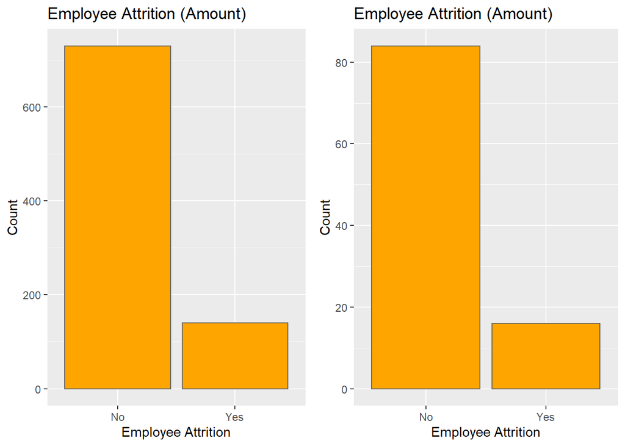

```r
##In numbers
g1 <- case2 %>% group_by(Attrition) %>% summarise(Count=n()) %>% ggplot(aes(x=Attrition, y=Count)) + geom_bar(stat="identity", fill="orange", color="grey40") +
labs(title="Employee Attrition (Amount)", x="Employee Attrition",y="Count")

##In percentage
g2 <- case2 %>% group_by(Attrition) %>% summarise(Count=n()) %>% mutate(pct=round(prop.table(Count),2) * 100) %>% ggplot(aes(x=Attrition, y=pct)) + geom_bar(stat="identity", fill="orange", color="grey40") +
labs(title="Employee Attrition (Amount)", x="Employee Attrition",y="Count")

grid.arrange(g1,g2,ncol = 2, nrow = 1)
```

```r
#print(arrangeGrob(g1,g2,ncol = 2, nrow = 1))
```

There are 84% “No” and 16% “Yes”, so we are having dominately “No” in our labeling for later modeling, we may have to deal with this imbalance problem in modeling

We are exploring Attrition with some other key variables

Attrition grouped by Gender

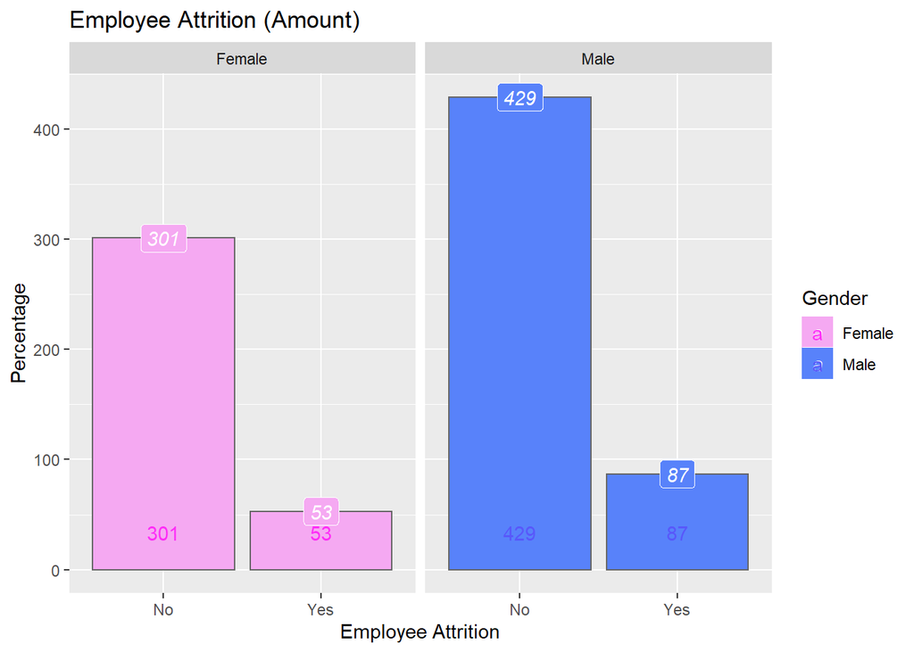

```r
g3 <- case2 %>% select(Gender, Age, Attrition) %>% filter(Gender == 'Male') %>%  group_by(Attrition) %>% summarise(Count=n()) %>% ggplot(aes(x=Attrition, y=Count)) + geom_bar(stat="identity", fill="#819FF7", color="grey40") +
    geom_label(aes(label=n, fill = Gender), colour = "white", fontface = "italic") +
  labs(title="Male Employee Attrition (Amount)", x="Employee Attrition",y="Count") + geom_text(aes(x=Attrition, y=0.01, label= Count),vjust=-2)

g4 <- case2 %>% select(Gender, Age, Attrition) %>% filter(Gender == 'Female') %>%  group_by(Attrition) %>% summarise(Count=n()) %>% ggplot(aes(x=Attrition, y=Count)) + geom_bar(stat="identity", fill="#F781F3", color="grey40") +
    geom_label(aes(label=n, fill = Gender), colour = "white", fontface = "italic") +
  labs(title="Female Employee Attrition (Amount)", x="Employee Attrition",y="Count") + geom_text(aes(x=Attrition, y=0.01, label= Count),vjust=-2)

#grid.arrange(g3,g4,ncol = 2, nrow = 1)

g5 <- case2 %>% select(Gender, Attrition) %>% group_by(Gender, Attrition) %>% summarize(n=n()) %>% ggplot(aes(x=Attrition, y=n, fill=Gender, color=Gender)) + geom_bar(stat="identity", color="grey40") + scale_fill_manual(values=c("#F5A9F2", "#5882FA")) + scale_color_manual(values=c("#FE2EF7", "#5858FA")) + facet_wrap(~Gender) +
    geom_label(aes(label=n, fill = Gender), colour = "white", fontface = "italic") +
    labs(title="Employee Attrition (Amount)", x="Employee Attrition",y="Percentage") + geom_text(aes(x=Attrition, y=0.01, label= n),vjust=-2)

g5
```

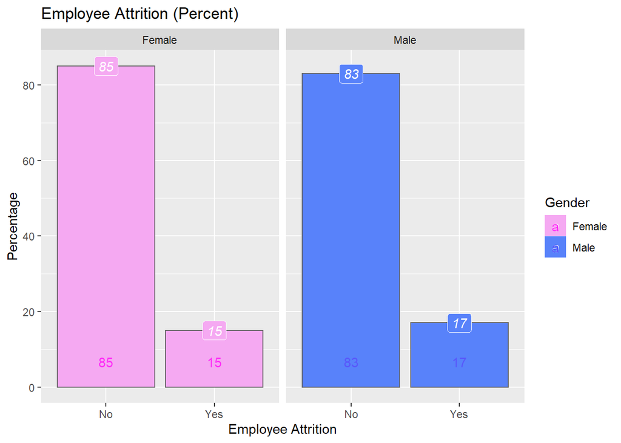

```r
g6 <- case2 %>% select(Gender, Attrition) %>% group_by(Gender, Attrition) %>% summarize(n=n()) %>% mutate(pct=round(prop.table(n),2) * 100) %>% ggplot(aes(x=Attrition, y=pct, fill=Gender, color=Gender)) + geom_bar(stat="identity", color="grey40") + scale_fill_manual(values=c("#F5A9F2", "#5882FA")) + scale_color_manual(values=c("#FE2EF7", "#5858FA")) + facet_wrap(~Gender) +
    geom_label(aes(label=pct, fill = Gender), colour = "white", fontface = "italic") +
    labs(title="Employee Attrition (Percent)", x="Employee Attrition",y="Percentage") + geom_text(aes(x=Attrition, y=0.01, label= pct),vjust=-2)

g6
```

We don’t identify big gender differences regarding Attrition rate.

Attrition grouped by Age

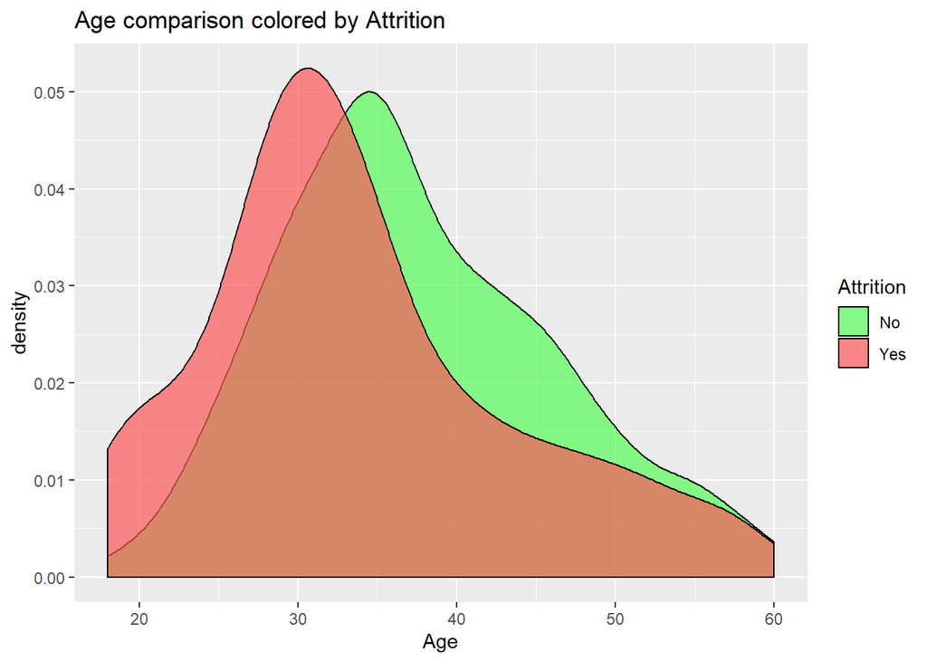

```r
g7 <- case2 %>% ggplot(aes(x=Age, fill=Attrition)) + geom_density(alpha = 0.7) + scale_color_manual(values=c("#58FA58", "#FA5858")) + scale_fill_manual(values=c("#58FA58", "#FA5858")) + labs(title="Age comparison colored by Attrition")

g7
```

The averaged employee age of Attrition of “Yes” is smaller than with “No”.

Attrition grouped by MonthlyIncome

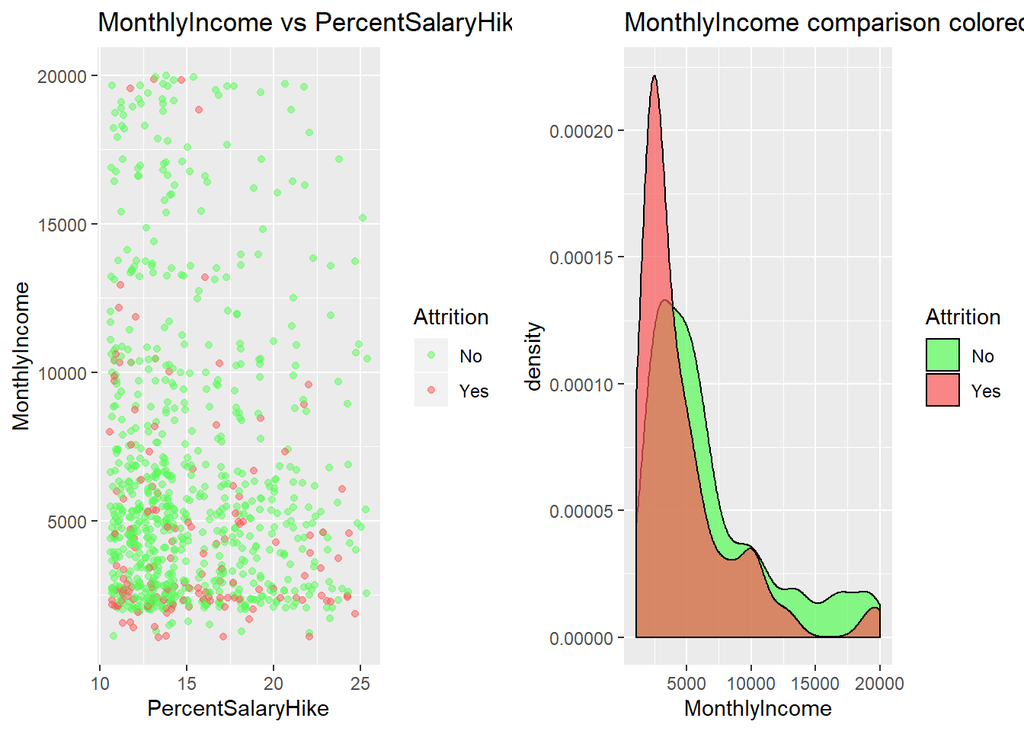

```r
g8<- case2 %>% select(Attrition, PercentSalaryHike, MonthlyIncome) %>%
ggplot(aes(x=PercentSalaryHike, y=MonthlyIncome)) + geom_jitter(aes(col=Attrition), alpha=0.5) + scale_color_manual(values=c("#58FA58", "#FA5858")) +
    labs(title="MonthlyIncome vs PercentSalaryHike colored by Attrition")

g9<-case2 %>% ggplot(aes(x=MonthlyIncome, fill=Attrition)) + geom_density(alpha = 0.7) + scale_color_manual(values=c("#58FA58", "#FA5858")) + scale_fill_manual(values=c("#58FA58", "#FA5858")) + labs(title="MonthlyIncome comparison colored by Attrition")

grid.arrange(g8,g9,ncol = 2, nrow = 1)
```

People did attrition has an average lower monthlyincome than the ones stay in the company.

Attrition grouped by MonthlyRate, DailyRate, HourlyRate

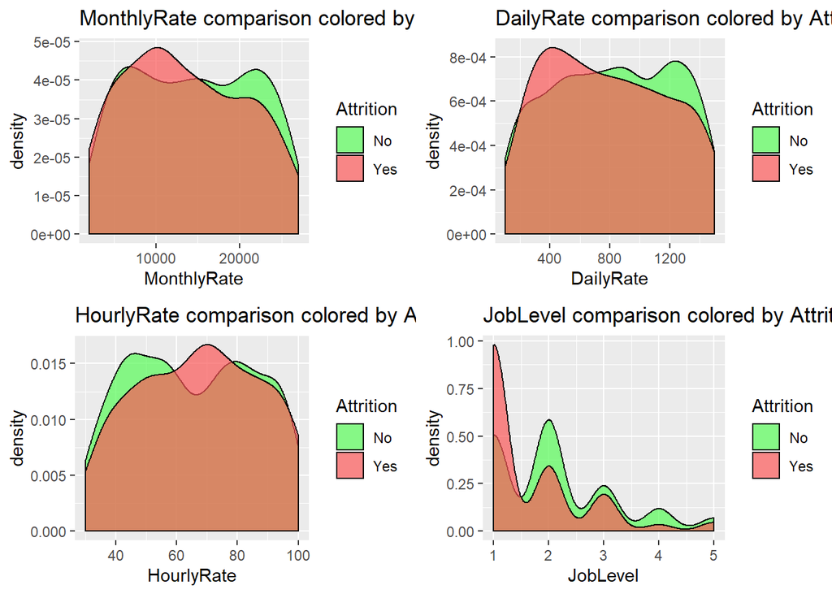

```r
g10<-case2 %>% ggplot(aes(x=MonthlyRate, fill=Attrition)) + geom_density(alpha = 0.7) + scale_color_manual(values=c("#58FA58", "#FA5858"))  + scale_fill_manual(values=c("#58FA58", "#FA5858"))+ labs(title="MonthlyRate comparison colored by Attrition")

g11<-case2 %>% ggplot(aes(x=DailyRate, fill=Attrition)) + geom_density(alpha = 0.7) + scale_color_manual(values=c("#58FA58", "#FA5858"))  + scale_fill_manual(values=c("#58FA58", "#FA5858"))+ labs(title="DailyRate comparison colored by Attrition")

g12<-case2 %>% ggplot(aes(x=HourlyRate, fill=Attrition)) + geom_density(alpha = 0.7) + scale_color_manual(values=c("#58FA58", "#FA5858"))  + scale_fill_manual(values=c("#58FA58", "#FA5858"))+ labs(title="HourlyRate comparison colored by Attrition")

g14<-case2 %>% ggplot(aes(x=JobLevel, fill=Attrition)) + geom_density(alpha = 0.7) + scale_color_manual(values=c("#58FA58", "#FA5858"))  + scale_fill_manual(values=c("#58FA58", "#FA5858"))+ labs(title="JobLevel comparison colored by Attrition")

grid.arrange(g10,g11,g12,g14,ncol = 2, nrow = 2)
```

We identified that it shows lower MonthlyRate/DailyRate for attrition “Yes”, not clear in HourlyRate. We observed that attrition “Yes” has lower Joblevel in general.

Attrition grouped by MonthlyIncome together with JobSatisfaction

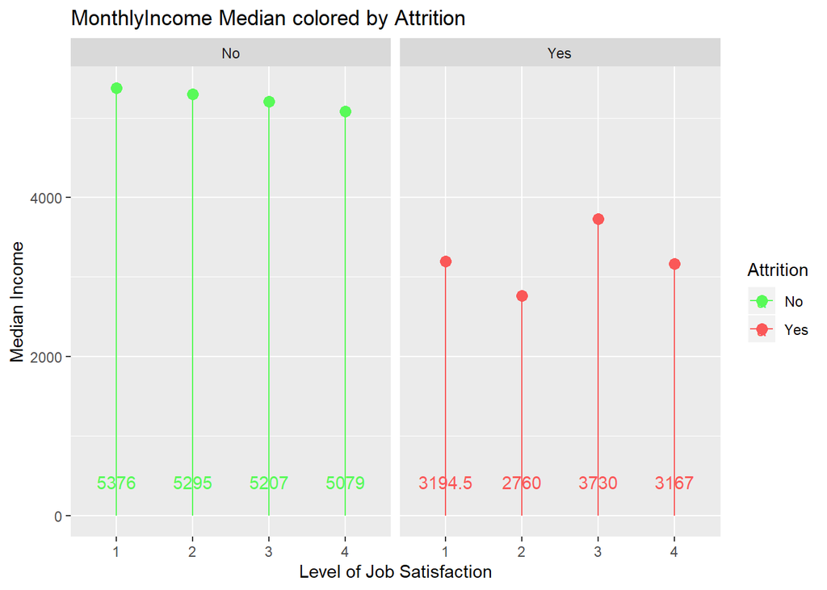

```r
case2$JobSatisfaction <- as.factor(case2$JobSatisfaction)


g15 <- case2 %>% select(JobSatisfaction, MonthlyIncome, Attrition) %>% group_by(JobSatisfaction, Attrition) %>% summarize(med=median(MonthlyIncome)) %>% ggplot(aes(x=JobSatisfaction, y=med, color=Attrition)) + geom_point(size=3) + facet_wrap(~Attrition) + labs(title="MonthlyIncome Median colored by Attrition", y="Median Income", x="Level of Job Satisfaction") + geom_segment(aes(x=JobSatisfaction,xend=JobSatisfaction, y=0, yend=med)) +  scale_color_manual(values=c("#58FA58", "#FA5858")) + scale_fill_manual(values=c("#58FA58", "#FA5858")) + geom_text(aes(x=JobSatisfaction, y=0.01, label= med),vjust=-2)

g15
```

In the group of Attrition people has an apparent lower median Income with the people who do not quit across job satisfaction levels.

Attrition grouped by Overtime

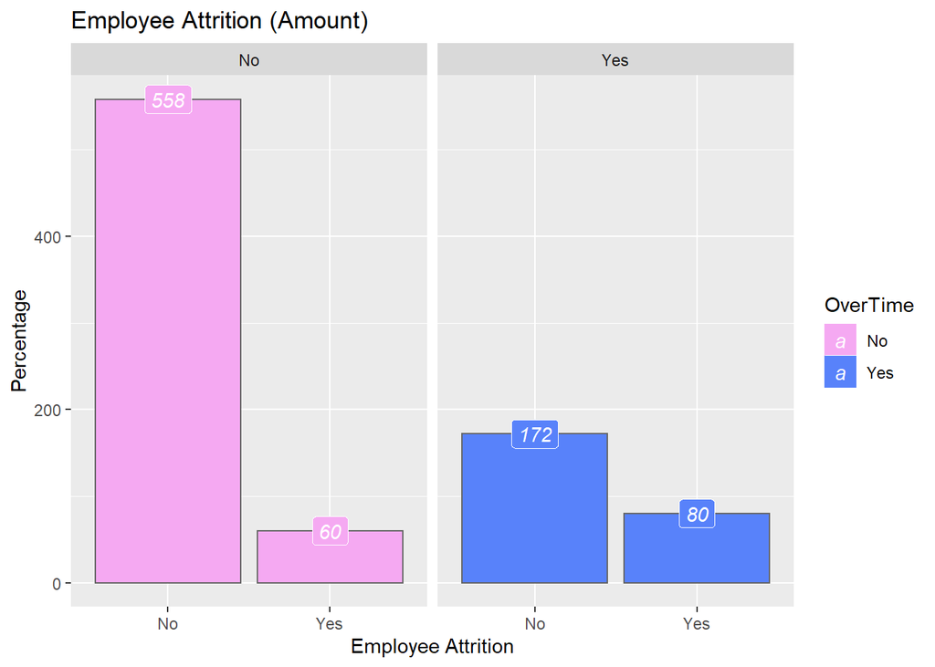

```r
g16 <- case2 %>% select(OverTime, Attrition) %>% group_by(OverTime, Attrition) %>% summarize(n=n()) %>% ggplot(aes(x=Attrition, y=n, fill=OverTime, color=OverTime)) + geom_bar(stat="identity", color="grey40") + scale_fill_manual(values=c("#F5A9F2", "#5882FA")) + scale_color_manual(values=c("#FE2EF7", "#5858FA")) + facet_wrap(~OverTime) +
    geom_label(aes(label=n, fill = OverTime), colour = "white", fontface = "italic") +
    labs(title="Employee Attrition (Amount)", x="Employee Attrition",y="Percentage")

g16
```

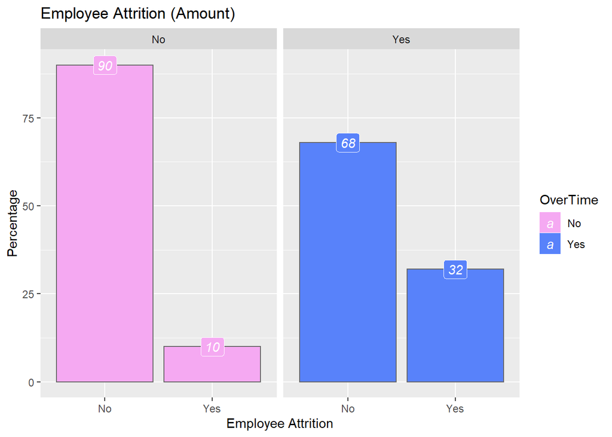

```r
g17 <- case2 %>% select(OverTime, Attrition) %>% group_by(OverTime, Attrition) %>% summarize(n=n()) %>% mutate(pct=round(prop.table(n),2) * 100) %>% ggplot(aes(x=Attrition, y=pct, fill=OverTime, color=OverTime)) + geom_bar(stat="identity", color="grey40") + scale_fill_manual(values=c("#F5A9F2", "#5882FA")) + scale_color_manual(values=c("#FE2EF7", "#5858FA")) + facet_wrap(~OverTime) +
  geom_label(aes(label=pct, fill = OverTime), colour = "white", fontface = "italic") +
    labs(title="Employee Attrition (Amount)", x="Employee Attrition",y="Percentage")

g17
```

People that has work overtime has a high probability of leaving the company.

Attrition grouped by Department

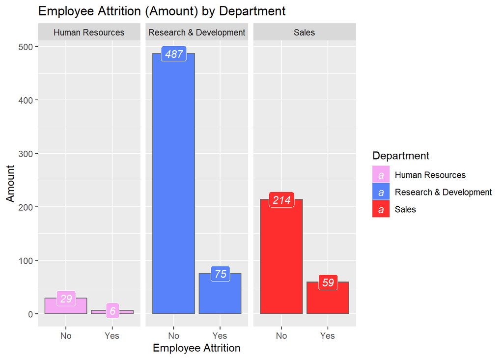

```r
g18 <- case2 %>% select(Department, Attrition) %>% group_by(Department, Attrition) %>% summarize(n=n()) %>% ggplot(aes(x=Attrition, y=n, fill=Department, color=Department)) + geom_bar(stat="identity", color="grey40") + scale_fill_manual(values=c("#F5A9F2", "#5882FA","#FE2E2E")) + scale_color_manual(values=c("#FE2EF7", "#5858FA","#FE2E2E")) + facet_wrap(~Department) +
  geom_label(aes(label=n, fill = Department), colour = "white", fontface = "italic") +
    labs(title="Employee Attrition (Amount) by Department", x="Employee Attrition",y="Amount")

g18
```

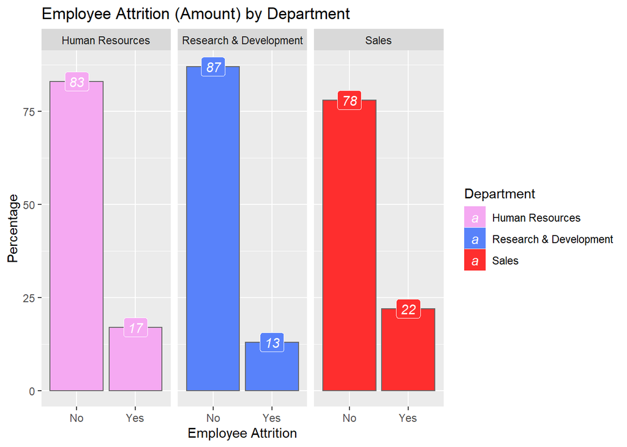

```r
g19 <- case2 %>% select(Department, Attrition) %>% group_by(Department, Attrition) %>% summarize(n=n()) %>% mutate(pct=round(prop.table(n),2) * 100) %>%
  ggplot(aes(x=Attrition, y=pct, fill=Department, color=Department)) + geom_bar(stat="identity", color="grey40") + scale_fill_manual(values=c("#F5A9F2", "#5882FA","#FE2E2E")) + scale_color_manual(values=c("#FE2EF7", "#5858FA","#FE2E2E")) + facet_wrap(~Department) +
  geom_label(aes(label=pct, fill = Department), colour = "white", fontface = "italic") +
    labs(title="Employee Attrition (Amount) by Department", x="Employee Attrition",y="Percentage")

g19
```

The Sales department has a higher probability of leaving the company.

Attrition grouped by WorkLifeBalance

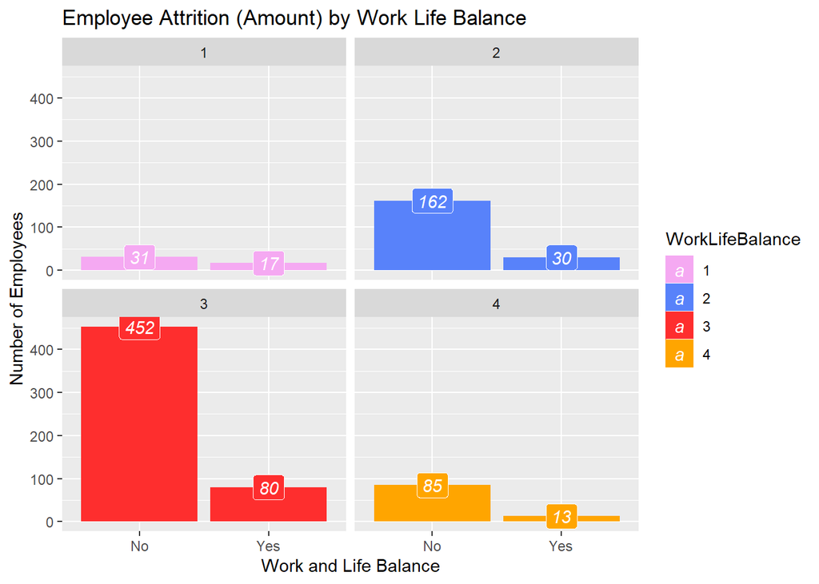

```r
case2$WorkLifeBalance <- as.factor(case2$WorkLifeBalance)

g20 <- case2 %>% select(WorkLifeBalance, Attrition) %>% group_by(WorkLifeBalance, Attrition) %>% summarize(count=n()) %>% ggplot(aes(x=fct_reorder(Attrition, -count), y=count, fill=WorkLifeBalance)) + geom_bar(stat='identity') + facet_wrap(~WorkLifeBalance) + scale_fill_manual(values=c("#F5A9F2", "#5882FA", "#FE2E2E","orange")) +  geom_label(aes(label=count, fill = WorkLifeBalance), colour = "white", fontface = "italic") +  labs(title="Employee Attrition (Amount) by Work Life Balance", x="Work and Life Balance", y="Number of Employees")

g20
```

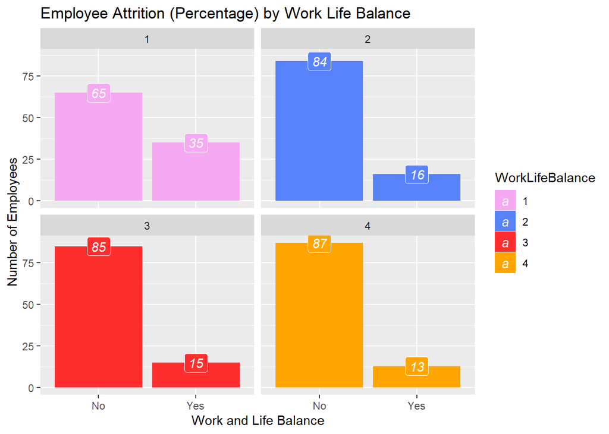

```r
g21 <- case2 %>% select(WorkLifeBalance, Attrition) %>% group_by(WorkLifeBalance, Attrition) %>% summarize(count=n()) %>% mutate(pct=round(prop.table(count),2) * 100) %>% ggplot(aes(x=fct_reorder(Attrition, -count), y=pct, fill=WorkLifeBalance)) + geom_bar(stat='identity') + facet_wrap(~WorkLifeBalance) + scale_fill_manual(values=c("#F5A9F2", "#5882FA", "#FE2E2E","orange")) + geom_label(aes(label=pct, fill = WorkLifeBalance), colour = "white", fontface = "italic") + labs(title="Employee Attrition (Percentage) by Work Life Balance", x="Work and Life Balance", y="Number of Employees")

g21
```

The worse the work life balance group has a highest ratio of people that are leaving.

Attrition grouped by BusinessTravel frequency

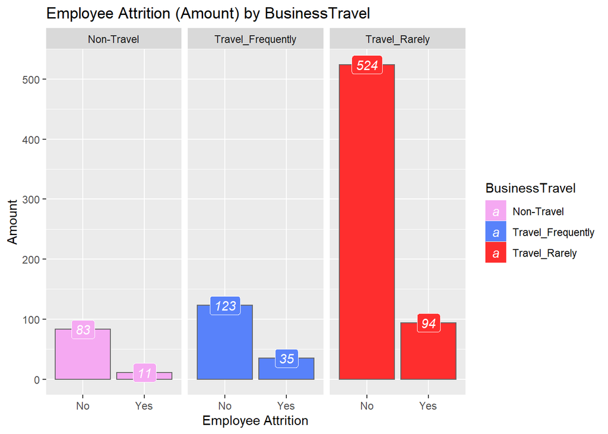

```r
g22 <- case2 %>% select(BusinessTravel, Attrition) %>% group_by(BusinessTravel, Attrition) %>% summarize(n=n()) %>% ggplot(aes(x=Attrition, y=n, fill=BusinessTravel, color=BusinessTravel)) + geom_bar(stat="identity", color="grey40") + scale_fill_manual(values=c("#F5A9F2", "#5882FA","#FE2E2E")) + scale_color_manual(values=c("#FE2EF7", "#5858FA","#FE2E2E")) + facet_wrap(~BusinessTravel) +
  geom_label(aes(label=n, fill = BusinessTravel), colour = "white", fontface = "italic") +
    labs(title="Employee Attrition (Amount) by BusinessTravel", x="Employee Attrition",y="Amount")

g22
```

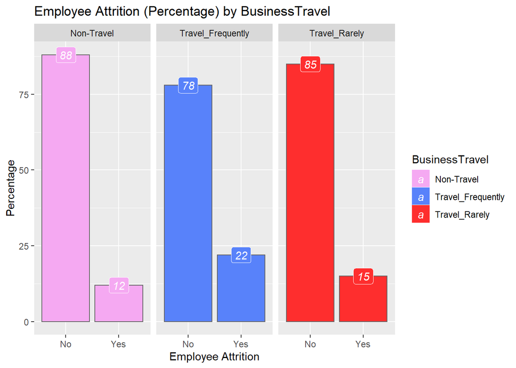

```r
g23 <- case2 %>% select(BusinessTravel, Attrition) %>% group_by(BusinessTravel, Attrition) %>% summarize(n=n()) %>% mutate(pct=round(prop.table(n),2) * 100) %>%
  ggplot(aes(x=Attrition, y=pct, fill=BusinessTravel, color=BusinessTravel)) + geom_bar(stat="identity", color="grey40") + scale_fill_manual(values=c("#F5A9F2", "#5882FA","#FE2E2E")) + scale_color_manual(values=c("#FE2EF7", "#5858FA","#FE2E2E")) + facet_wrap(~BusinessTravel) +
  geom_label(aes(label=pct, fill = BusinessTravel), colour = "white", fontface = "italic") +
    labs(title="Employee Attrition (Percentage) by BusinessTravel", x="Employee Attrition",y="Percentage")

g23
```

The group of Travel_Frequently has a higher probability of leaving the company.

Attrition grouped by YearsatCompanies, etc

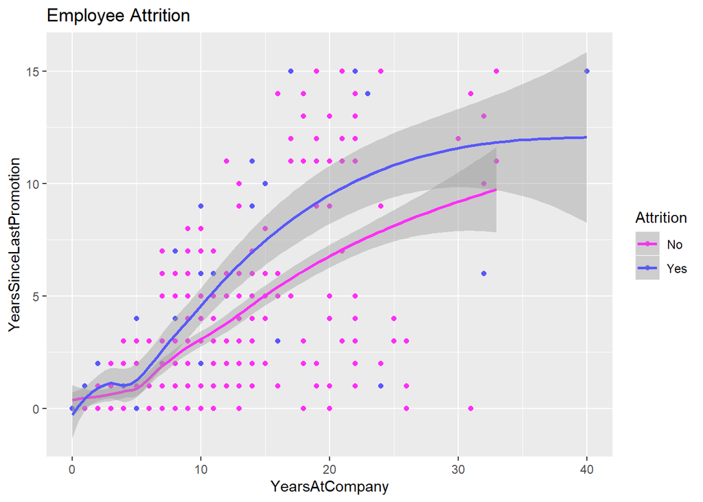

```r
g24 <- case2 %>% select(YearsAtCompany, YearsSinceLastPromotion,Attrition) %>%
ggplot(aes(x=YearsAtCompany, y=YearsSinceLastPromotion, colour = Attrition))+ geom_point()  + geom_smooth(method="loess") + scale_color_manual(values=c("#FE2EF7", "#5858FA")) +
    labs(title="Employee Attrition", x="YearsAtCompany",y="YearsSinceLastPromotion")

g24
```

The different fitting show that people stay longer in company without promotion will likely to quit.

## The response variable: MonthlyIncome

Remove the variables with no valid information

```r
case2_use <- case2

# Delete unecessary columns
cols <- c("ID","Over18", "EmployeeNumber", "EmployeeCount", "StandardHours")

case2_use[cols] <- NULL
```

Correlation Matrix

```r
numericVars <- which(sapply(case2_use, is.numeric)) #index vector numeric variables
numericVarNames <- names(numericVars) #saving names vector for use later on
cat('There are', length(numericVars), 'numeric variables')
```

```
## There are 21 numeric variables
```

```r
case2_numVar <- case2_use[, numericVars]
cor_numVar <- cor(case2_numVar, use="pairwise.complete.obs") #correlations of all numeric variables

#sort on decreasing correlations with MonthlyIncome
cor_sorted <- as.matrix(sort(cor_numVar[,'MonthlyIncome'], decreasing = TRUE))
 #select only high corelations
CorHigh <- names(which(apply(cor_sorted, 1, function(x) abs(x)>0.1)))
cor_numVar <- cor_numVar[CorHigh, CorHigh]

#corrplot.mixed(cor_numVar, tl.col="black", tl.pos = "lt")
```

Plot High correlated variables:

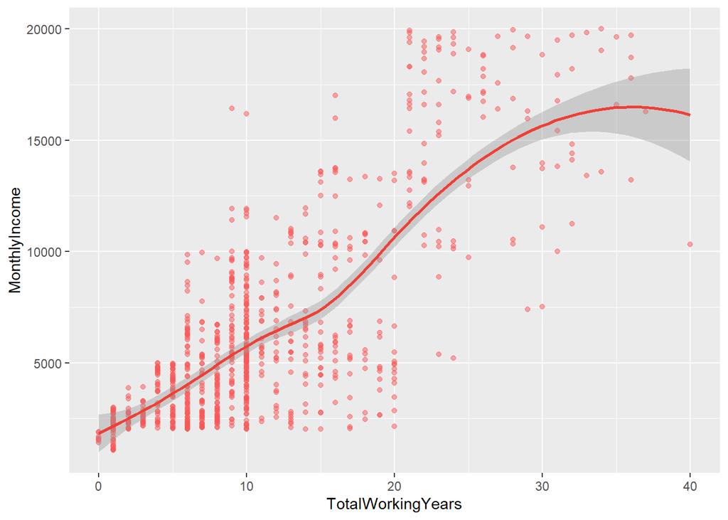

```r
#Total working years
g27 <- case2 %>% select(TotalWorkingYears, MonthlyIncome) %>%
ggplot(aes(x=TotalWorkingYears, y=MonthlyIncome)) + geom_point(colour = "#FA5858", alpha=1/2) + geom_smooth(method="loess",color="#EE4037")

g28 <- case2 %>% select(YearsAtCompany, MonthlyIncome) %>%
ggplot(aes(x=YearsAtCompany, y=MonthlyIncome)) + geom_point(colour = "#FA5858", alpha=1/2) + geom_smooth(method="loess",color="#EE4037")

g29 <- case2 %>% select(Age, MonthlyIncome) %>%
ggplot(aes(x=Age, y=MonthlyIncome)) + geom_point(colour = "#FA5858", alpha=1/2) + geom_smooth(method="loess",color="#EE4037")

g30 <- case2 %>% select(JobLevel, MonthlyIncome) %>%
ggplot(aes(x=JobLevel, y=MonthlyIncome)) + geom_point(colour = "#FA5858", alpha=1/2) + geom_smooth(method="loess",color="#EE4037")

g31 <- case2 %>% select(YearsAtCompany, YearsInCurrentRole,YearsSinceLastPromotion,YearsWithCurrManager) %>% ggpairs()

g27
```

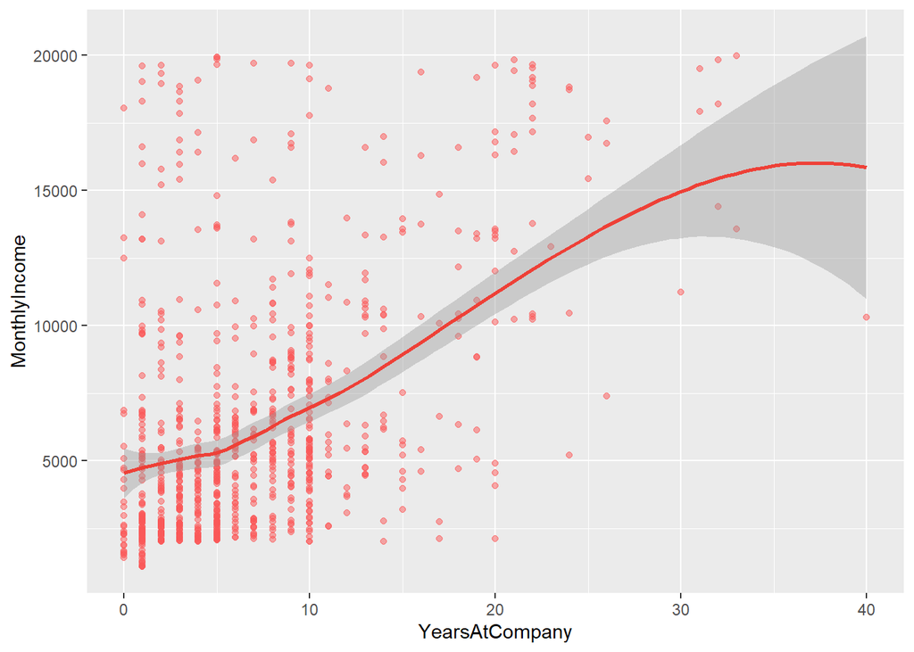

```r
g28
```

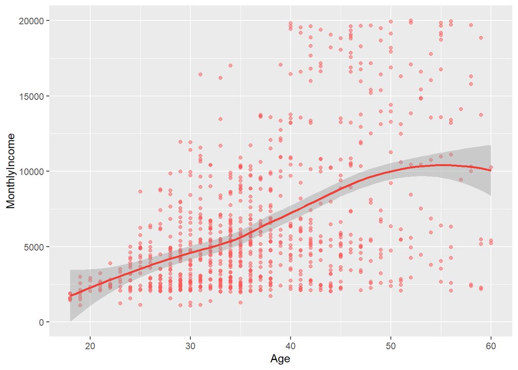

```r
g29
```

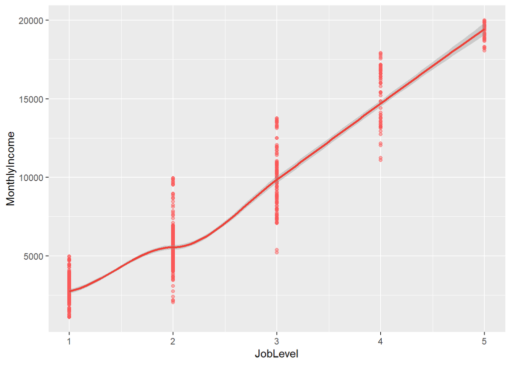

```r
g30
```

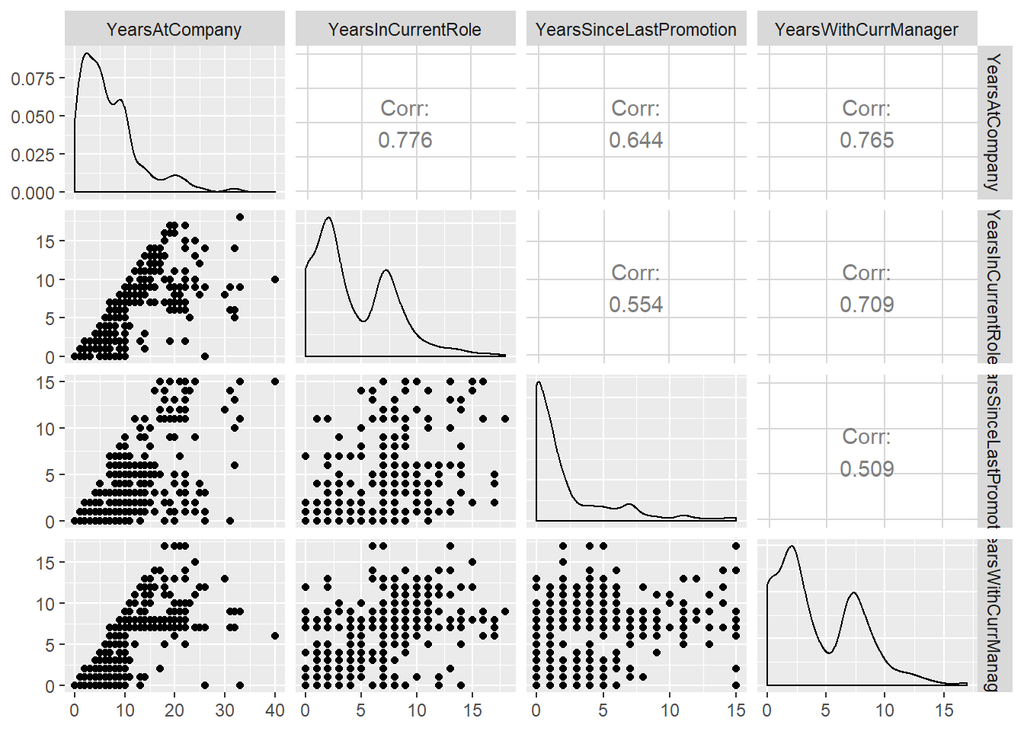

```r
g31
```

Investigate Monthly Income by Gender

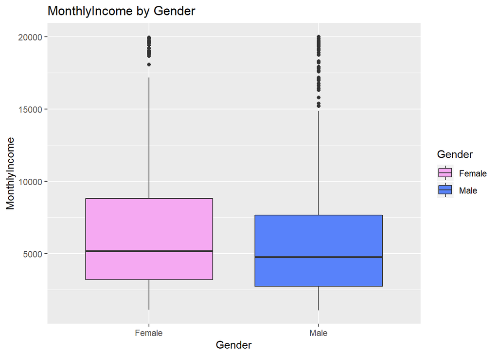

```r
g32 <- case2 %>% group_by(Gender) %>% ggplot(aes(x=Gender, y=MonthlyIncome,fill=Gender)) + geom_boxplot() + scale_fill_manual(values=c("#F5A9F2", "#5882FA","#FE2E2E")) + scale_color_manual(values=c("#FE2EF7", "#5858FA","#FE2E2E"))  +
labs(title="MonthlyIncome by Gender")
g32
```

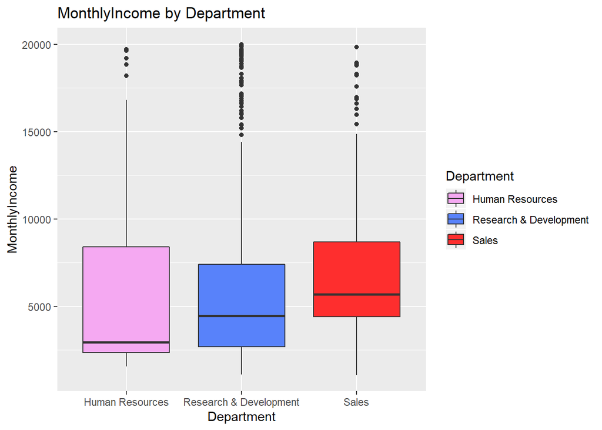

```r
g33 <- case2 %>% group_by(Department) %>% ggplot(aes(x=Department, y=MonthlyIncome,fill=Department)) + geom_boxplot() + scale_fill_manual(values=c("#F5A9F2", "#5882FA","#FE2E2E")) + scale_color_manual(values=c("#FE2EF7", "#5858FA","#FE2E2E")) +
labs(title="MonthlyIncome by Department")
g33
```

#Modeling

##First I removed several variables that are not informative

```r
case2_use <- case2
# Delete unecessary columns
cols <- c("Over18", "EmployeeNumber", "EmployeeCount","ID","StandardHours")

case2_use[cols] <- NULL
```

Split the data

```r
set.seed(1000)
# Splitting our data
trainIndex <- createDataPartition(case2_use$Attrition, p=0.7,
                                 list=FALSE, times=1)

train_case2 <- case2_use[trainIndex,]
valid_case2 <- case2_use[-trainIndex,]

train_case2_label <- case2_use[trainIndex,]$Attrition
valid_case2_label <- case2_use[-trainIndex,]$Attrition

head(train_case2)
```

```
##   Age Attrition    BusinessTravel DailyRate             Department
## 1  32        No     Travel_Rarely       117                  Sales
## 2  40        No     Travel_Rarely      1308 Research & Development
## 3  35        No Travel_Frequently       200 Research & Development
## 4  32        No     Travel_Rarely       801                  Sales
## 5  24        No Travel_Frequently       567 Research & Development
## 6  27        No Travel_Frequently       294 Research & Development
##   DistanceFromHome Education   EducationField EnvironmentSatisfaction
## 1               13         4    Life Sciences                       2
## 2               14         3          Medical                       3
## 3               18         2    Life Sciences                       3
## 4                1         4        Marketing                       3
## 5                2         1 Technical Degree                       1
## 6               10         2    Life Sciences                       4
##   Gender HourlyRate JobInvolvement JobLevel                JobRole
```

[output cut: 41 more lines]

```r
head(valid_case2)
```

```
##    Age Attrition BusinessTravel DailyRate             Department
## 9   34        No  Travel_Rarely      1333                  Sales
## 12  28        No     Non-Travel       280        Human Resources
## 16  31        No     Non-Travel      1188                  Sales
## 19  34        No  Travel_Rarely       181 Research & Development
## 20  44        No  Travel_Rarely       170 Research & Development
## 28  33       Yes  Travel_Rarely       603                  Sales
##    DistanceFromHome Education EducationField EnvironmentSatisfaction
## 9                10         4  Life Sciences                       3
## 12                1         2  Life Sciences                       3
## 16               20         2      Marketing                       4
## 19                2         4        Medical                       4
## 20                1         4  Life Sciences                       2
## 28                9         4      Marketing                       1
##    Gender HourlyRate JobInvolvement JobLevel                   JobRole
```

[output cut: 41 more lines]

Use naive bayes

```r
model = naiveBayes(train_case2[,-c(2)],as.factor(train_case2$Attrition), laplace = 0)
Table_nb <- table(predict(model,valid_case2[,-c(2)]),valid_case2$Attrition)
CM_nb = confusionMatrix(Table_nb )
CM_nb
```

```
## Confusion Matrix and Statistics
##
##
##        No Yes
##   No  190  16
##   Yes  29  26
##
##                Accuracy : 0.8276
##                  95% CI : (0.7762, 0.8714)
##     No Information Rate : 0.8391
##     P-Value [Acc > NIR] : 0.72638
##
##                   Kappa : 0.4325
##
##  Mcnemar's Test P-Value : 0.07364
##
##             Sensitivity : 0.8676
##             Specificity : 0.6190
##          Pos Pred Value : 0.9223
##          Neg Pred Value : 0.4727
##              Prevalence : 0.8391
##          Detection Rate : 0.7280
##    Detection Prevalence : 0.7893
##       Balanced Accuracy : 0.7433
##
##        'Positive' Class : No
##
```

##Many Modeling approaches doesn’t take category variables so we picked the variables that are numerical

```r
numeric=case2_use %>% dplyr::select(Age,DailyRate,DistanceFromHome,HourlyRate,MonthlyRate,MonthlyIncome,NumCompaniesWorked,PercentSalaryHike,TrainingTimesLastYear,YearsAtCompany,YearsInCurrentRole,YearsSinceLastPromotion,YearsWithCurrManager,TotalWorkingYears)

#scale the data:
num=list(names(numeric))
case2_use_num=case2_use[,names(case2_use) %in% num[[1]]]
```

Split the data

```r
set.seed(1000)
# Splitting our data
trainIndex <- createDataPartition(case2_use$Attrition, p=0.7,
                                 list=FALSE, times=1)

train_case2 <- case2_use_num[trainIndex,]
valid_case2 <- case2_use_num[-trainIndex,]

train_case2_label <- case2_use[trainIndex,]$Attrition
valid_case2_label <- case2_use[-trainIndex,]$Attrition
```

Use naive bayes

```r
model = naiveBayes(train_case2,as.factor(train_case2_label), laplace = 0)
Table_nb <- table(predict(model,valid_case2),valid_case2_label)
CM_nb = confusionMatrix(Table_nb )
CM_nb
```

```
## Confusion Matrix and Statistics
##
##      valid_case2_label
##        No Yes
##   No  189  23
##   Yes  30  19
##
##                Accuracy : 0.7969
##                  95% CI : (0.743, 0.844)
##     No Information Rate : 0.8391
##     P-Value [Acc > NIR] : 0.9707
##
##                   Kappa : 0.2955
##
##  Mcnemar's Test P-Value : 0.4098
##
##             Sensitivity : 0.8630
##             Specificity : 0.4524
##          Pos Pred Value : 0.8915
##          Neg Pred Value : 0.3878
##              Prevalence : 0.8391
##          Detection Rate : 0.7241
##    Detection Prevalence : 0.8123
##       Balanced Accuracy : 0.6577
##
##        'Positive' Class : No
##
```

The results from the NB method is not too bad: We get 0.86 for Sensitivity and 45 for Specificity.

Use KNN

```r
model_knn = knn(train_case2,valid_case2,train_case2_label, prob = FALSE, k = 3)
table(model_knn,valid_case2_label)
```

```
##          valid_case2_label
## model_knn  No Yes
##       No  209  37
##       Yes  10   5
```

```r
CM_knn = confusionMatrix(table(model_knn,valid_case2_label))
CM_knn
```

```
## Confusion Matrix and Statistics
##
##          valid_case2_label
## model_knn  No Yes
##       No  209  37
##       Yes  10   5
##
##                Accuracy : 0.8199
##                  95% CI : (0.7678, 0.8646)
##     No Information Rate : 0.8391
##     P-Value [Acc > NIR] : 0.8236947
##
##                   Kappa : 0.0991
##
##  Mcnemar's Test P-Value : 0.0001491
##
##             Sensitivity : 0.9543
##             Specificity : 0.1190
##          Pos Pred Value : 0.8496
##          Neg Pred Value : 0.3333
##              Prevalence : 0.8391
##          Detection Rate : 0.8008
##    Detection Prevalence : 0.9425
##       Balanced Accuracy : 0.5367
##
##        'Positive' Class : No
##
```

The KNN method give us really high 0.95 for Sensitivity but really low 0.12 for Specificity, this is unacceptable.

##Transfer the data: We convert category variables to ordinal variables We found that some of the category variables can be converted to ordinal variables, it will add more variables for the fitting.

```r
numericandordinal=case2_use %>% dplyr::select(Age,DailyRate,DistanceFromHome,HourlyRate,MonthlyRate,MonthlyIncome,NumCompaniesWorked,PercentSalaryHike,TrainingTimesLastYear,YearsAtCompany,YearsInCurrentRole,YearsSinceLastPromotion,YearsWithCurrManager,TotalWorkingYears,BusinessTravel,OverTime,EnvironmentSatisfaction,Education,JobInvolvement,JobLevel,PerformanceRating,RelationshipSatisfaction,StockOptionLevel)

#scale the data:
num2=list(names(numericandordinal))
case2_use_numadd=case2_use[,names(case2_use) %in% num2[[1]]]

case2_use_numadd <- case2_use_numadd %>% mutate(BusinessTravel=factor(BusinessTravel)) %>% mutate(BusinessTravel=fct_recode(BusinessTravel,"1"="Travel_Frequently","2"="Travel_Rarely","3"="Non-Travel"))
case2_use_numadd <- case2_use_numadd %>% mutate(OverTime=factor(OverTime)) %>% mutate(OverTime=fct_recode(OverTime,"0"="No","1"="Yes"))
case2_use_numadd <- case2_use_numadd %>% mutate(EnvironmentSatisfaction=factor(EnvironmentSatisfaction)) %>% mutate(EnvironmentSatisfaction=fct_recode(EnvironmentSatisfaction,"1"="Low","2"="Medium","3"="High","4"="Very High"))
cols <- c("Education", "JobInvolvement", "JobLevel","PerformanceRating","RelationshipSatisfaction","StockOptionLevel")
case2_use_numadd[cols] <- lapply(case2_use_numadd[cols], factor)

#str(case2_use_numadd)
```

Split the data

```r
set.seed(1000)
# Splitting our data
trainIndex <- createDataPartition(case2_use$Attrition, p=0.7,
                                 list=FALSE, times=1)

train_case2 <- case2_use_numadd[trainIndex,]
valid_case2 <- case2_use_numadd[-trainIndex,]

train_case2_label <- case2_use[trainIndex,]$Attrition
valid_case2_label <- case2_use[-trainIndex,]$Attrition
```

Use naive bayes

```r
model = naiveBayes(train_case2,as.factor(train_case2_label), laplace = 0)
Table_nb <- table(predict(model,valid_case2),valid_case2_label)
CM_nb = confusionMatrix(Table_nb )
CM_nb
```

```
## Confusion Matrix and Statistics
##
##      valid_case2_label
##        No Yes
##   No  191  21
##   Yes  28  21
##
##                Accuracy : 0.8123
##                  95% CI : (0.7595, 0.8578)
##     No Information Rate : 0.8391
##     P-Value [Acc > NIR] : 0.8950
##
##                   Kappa : 0.3487
##
##  Mcnemar's Test P-Value : 0.3914
##
##             Sensitivity : 0.8721
##             Specificity : 0.5000
##          Pos Pred Value : 0.9009
##          Neg Pred Value : 0.4286
##              Prevalence : 0.8391
##          Detection Rate : 0.7318
##    Detection Prevalence : 0.8123
##       Balanced Accuracy : 0.6861
##
##        'Positive' Class : No
##
```

```r
train_case2_add <- train_case2
train_case2_add$Attrition <- train_case2_label
valid_case2_add <- valid_case2
valid_case2_add$Attrition <- valid_case2_label

train_case2_add  <- train_case2_add  %>% mutate(Attrition=factor(Attrition)) %>% mutate(Attrition=fct_recode(Attrition,"0"="No","1"="Yes"))
valid_case2_add  <- valid_case2_add  %>% mutate(Attrition=factor(Attrition)) %>% mutate(Attrition=fct_recode(Attrition,"0"="No","1"="Yes"))
```

Use KNN-cat

```r
library(knncat)
model_knncat = knncat(train_case2_add,classcol = 24)
knncat_pred <- predict(model_knncat, train_case2_add, train.classcol = 24, valid_case2_add, newdata.classcol = 24)
CM_knncat = confusionMatrix(table(knncat_pred,valid_case2_add[,24]))
CM_knncat
```

```
## Confusion Matrix and Statistics
##
##
## knncat_pred   0   1
##           0 205  35
##           1  14   7
##
##                Accuracy : 0.8123
##                  95% CI : (0.7595, 0.8578)
##     No Information Rate : 0.8391
##     P-Value [Acc > NIR] : 0.894993
##
##                   Kappa : 0.1288
##
##  Mcnemar's Test P-Value : 0.004275
##
##             Sensitivity : 0.9361
##             Specificity : 0.1667
##          Pos Pred Value : 0.8542
##          Neg Pred Value : 0.3333
##              Prevalence : 0.8391
##          Detection Rate : 0.7854
##    Detection Prevalence : 0.9195
##       Balanced Accuracy : 0.5514
##
##        'Positive' Class : 0
##
```

The KNN get improved from original which has 0.17 for Specificity.

Use Random Forest

```r
## Classification Method 4: RandomForest
model_rf = randomForest(train_case2,as.factor(train_case2_label),ntree=500)
CM_rf = confusionMatrix(table(predict(model_rf,valid_case2),valid_case2_label))
CM_rf
```

```
## Confusion Matrix and Statistics
##
##      valid_case2_label
##        No Yes
##   No  214  37
##   Yes   5   5
##
##                Accuracy : 0.8391
##                  95% CI : (0.7888, 0.8815)
##     No Information Rate : 0.8391
##     P-Value [Acc > NIR] : 0.5411
##
##                   Kappa : 0.139
##
##  Mcnemar's Test P-Value : 1.724e-06
##
##             Sensitivity : 0.9772
##             Specificity : 0.1190
##          Pos Pred Value : 0.8526
##          Neg Pred Value : 0.5000
##              Prevalence : 0.8391
##          Detection Rate : 0.8199
##    Detection Prevalence : 0.9617
##       Balanced Accuracy : 0.5481
##
##        'Positive' Class : No
##
```

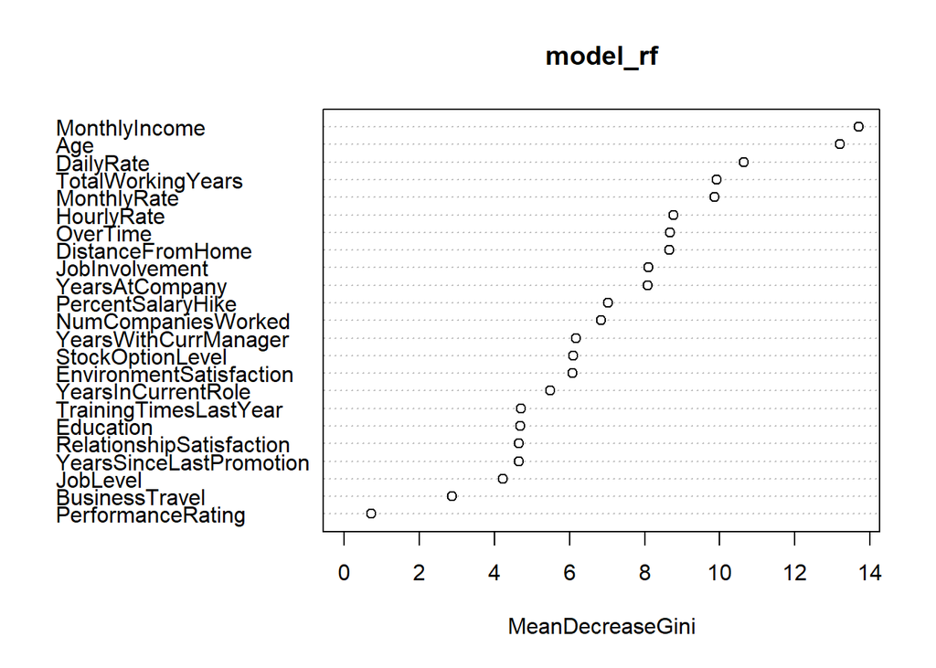

```r
## But random forest can provide with feature importance
varImpPlot(model_rf)
```

The specificity is still low in random forest. But we can reference to the feature importance map.

```r
# Delete lease important columns
cols <- c("PerformanceRating","BusinessTravel","YearsSinceLastPromotion","Education","TrainingTimesLastYear")

train_case2[cols] <- NULL
valid_case2[cols] <- NULL

model = naiveBayes(train_case2,as.factor(train_case2_label), laplace = 0)
Table_nb <- table(predict(model,valid_case2),valid_case2_label)
CM_nb = confusionMatrix(Table_nb )
CM_nb
```

```
## Confusion Matrix and Statistics
##
##      valid_case2_label
##        No Yes
##   No  192  16
##   Yes  27  26
##
##                Accuracy : 0.8352
##                  95% CI : (0.7846, 0.8781)
##     No Information Rate : 0.8391
##     P-Value [Acc > NIR] : 0.6066
##
##                   Kappa : 0.4483
##
##  Mcnemar's Test P-Value : 0.1273
##
##             Sensitivity : 0.8767
##             Specificity : 0.6190
##          Pos Pred Value : 0.9231
##          Neg Pred Value : 0.4906
##              Prevalence : 0.8391
##          Detection Rate : 0.7356
##    Detection Prevalence : 0.7969
##       Balanced Accuracy : 0.7479
##
##        'Positive' Class : No
##
```

The specificity has improved from 0.50 to 0.61.

What if we just go ahead and use all variables switching to numerical, will that help?

```r
##Convert the category variables to factors in numerical levels

temp <- case2_use %>% mutate(Gender=factor(Gender)) %>% mutate(Gender=fct_recode(Gender,"0"="Male","1"="Female"))
temp <- temp %>% mutate(BusinessTravel=factor(BusinessTravel)) %>% mutate(BusinessTravel=fct_recode(BusinessTravel,"1"="Travel_Frequently","2"="Travel_Rarely","3"="Non-Travel"))
temp <- temp %>% mutate(Attrition=factor(Attrition)) %>% mutate(Attrition=fct_recode(Attrition,"0"="No","1"="Yes"))
temp <- temp %>% mutate(MaritalStatus=factor(MaritalStatus)) %>% mutate(MaritalStatus=fct_recode(MaritalStatus,"0"="Married","1"="Single","2"="Divorced"))
temp <- temp %>% mutate(OverTime=factor(OverTime)) %>% mutate(OverTime=fct_recode(OverTime,"0"="No","1"="Yes"))
temp <- temp %>% mutate(Department=factor(Department)) %>% mutate(Department=fct_recode(Department,"0"="Sales","1"="Research & Development","2"="Human Resources"))
temp <- temp %>% mutate(JobRole=factor(JobRole)) %>% mutate(JobRole=fct_recode(JobRole,"0"="Healthcare Representative","1"="Sales Representative","2"="Research Scientist","3"="Manufacturing Director","4"="Sales Executive","5"="Human Resources","6"="Laboratory Technician","7"="Research Director","8"="Manager"))
temp <- temp %>% mutate(EducationField=factor(EducationField)) %>% mutate(EducationField=fct_recode(EducationField,"0"="Life Sciences","1"="Medical","2"="Technical Degree","3"="Marketing","4"="Human Resources", "5"="Other"))
temp <- temp %>% mutate(EnvironmentSatisfaction=factor(EnvironmentSatisfaction)) %>% mutate(EnvironmentSatisfaction=fct_recode(EnvironmentSatisfaction,"1"="Low","2"="Medium","3"="High","4"="Very High"))
case2_use_cat<-temp

cols <- c("Education", "JobInvolvement", "JobLevel","PerformanceRating","RelationshipSatisfaction","StockOptionLevel")
case2_use_cat[cols] <- lapply(case2_use_cat[cols], factor)
```

Split the data

```r
set.seed(1000)
# Splitting our data
trainIndex <- createDataPartition(case2_use_cat$Attrition, p=0.7,
                                 list=FALSE, times=1)

train_case2 <- case2_use_cat[trainIndex,]
valid_case2 <- case2_use_cat[-trainIndex,]
```

Use naive bayes

```r
cols <- c("PerformanceRating","BusinessTravel","YearsSinceLastPromotion","Education","TrainingTimesLastYear","JobLevel")

train_case2[cols] <- NULL
valid_case2[cols] <- NULL


model = naiveBayes(train_case2[,-c(2)],as.factor(train_case2$Attrition), laplace = 0)
Table_nb <- table(predict(model,valid_case2[,-c(2)]),valid_case2$Attrition)
CM_nb = confusionMatrix(Table_nb )
CM_nb
```

```
## Confusion Matrix and Statistics
##
##
##       0   1
##   0 192  15
##   1  27  27
##
##                Accuracy : 0.8391
##                  95% CI : (0.7888, 0.8815)
##     No Information Rate : 0.8391
##     P-Value [Acc > NIR] : 0.54107
##
##                   Kappa : 0.4658
##
##  Mcnemar's Test P-Value : 0.08963
##
##             Sensitivity : 0.8767
##             Specificity : 0.6429
##          Pos Pred Value : 0.9275
##          Neg Pred Value : 0.5000
##              Prevalence : 0.8391
##          Detection Rate : 0.7356
##    Detection Prevalence : 0.7931
##       Balanced Accuracy : 0.7598
##
##        'Positive' Class : 0
##
```

Use Random Forest

```r
## Classification Method 4: RandomForest
model_rf = randomForest(train_case2[,-c(2)],as.factor(train_case2$Attrition),ntree=500)
CM_rf = confusionMatrix(table(predict(model_rf,valid_case2[,-c(2)]),valid_case2$Attrition))
CM_rf
```

```
## Confusion Matrix and Statistics
##
##
##       0   1
##   0 215  37
##   1   4   5
##
##                Accuracy : 0.8429
##                  95% CI : (0.793, 0.8849)
##     No Information Rate : 0.8391
##     P-Value [Acc > NIR] : 0.474
##
##                   Kappa : 0.1477
##
##  Mcnemar's Test P-Value : 5.806e-07
##
##             Sensitivity : 0.9817
##             Specificity : 0.1190
##          Pos Pred Value : 0.8532
##          Neg Pred Value : 0.5556
##              Prevalence : 0.8391
##          Detection Rate : 0.8238
##    Detection Prevalence : 0.9655
##       Balanced Accuracy : 0.5504
##
##        'Positive' Class : 0
##
```

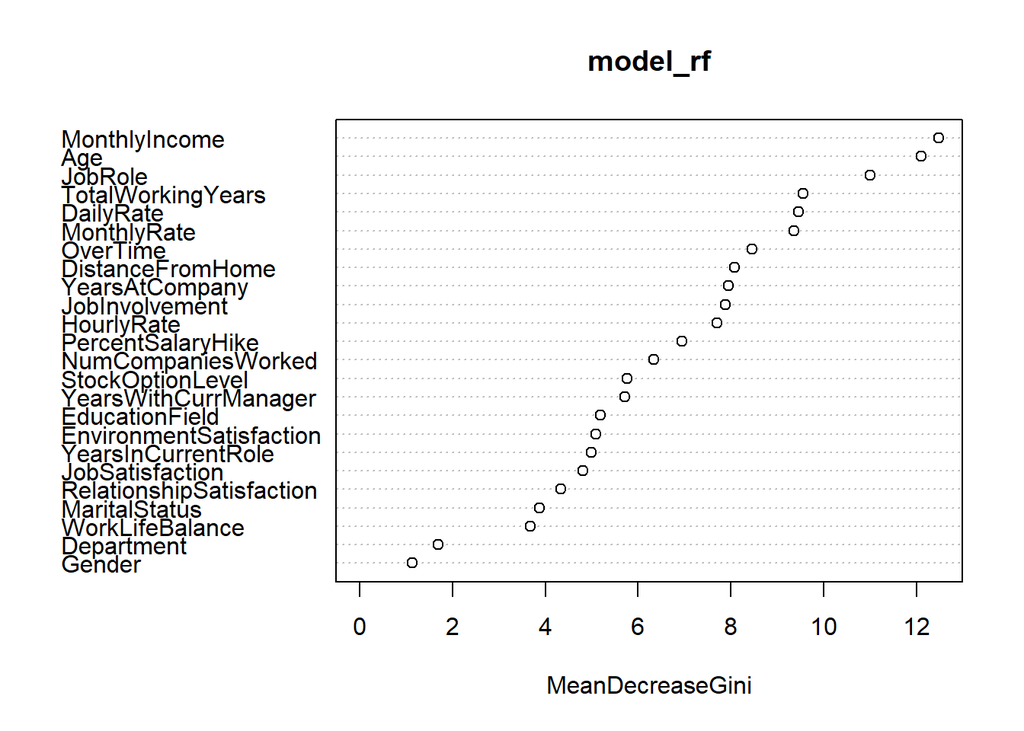

```r
## But random forest can provide with feature importance
varImpPlot(model_rf)
```

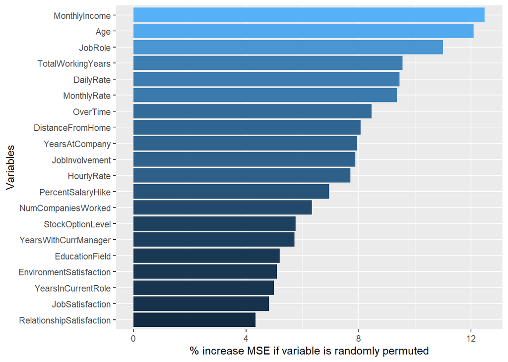

```r
imp_RF <- importance(model_rf)
imp_DF <- data.frame(Variables = row.names(imp_RF), MSE = imp_RF[,1])
imp_DF <- imp_DF[order(imp_DF$MSE, decreasing = TRUE),]

ggplot(imp_DF[1:20,], aes(x=reorder(Variables, MSE), y=MSE, fill=MSE)) + geom_bar(stat = 'identity') + labs(x = 'Variables', y= '% increase MSE if variable is randomly permuted') + coord_flip() + theme(legend.position="none")
```

Random forest doesn’t give us an improved results. It shows very low Specificity.

As we stated earlier in the EDA, the labels are imbalanced, we can balance the data and check if it can improve. we use SMOTE to deal with imbalance problem.

```r
p=prop.table(table(train_case2$Attrition))
cat("Before SMOTE the propotions are:"); print(p,row.names=FALSE)
```

```
## Before SMOTE the propotions are:
```

```
##
##         0         1
## 0.8390805 0.1609195
```

```r
set.seed(1000)
library(DMwR)
smote_train=SMOTE(Attrition ~ .,train_case2)
q=prop.table(table(smote_train$Attrition))
cat("After SMOTE the propotions are:"); print(q,row.names=FALSE)
```

```
## After SMOTE the propotions are:
```

```
##
##         0         1
## 0.5714286 0.4285714
```

```r
model = naiveBayes(smote_train[,-c(2)],as.factor(smote_train$Attrition), laplace = 0)
Table_nb_SMOTE <- table(predict(model,valid_case2[,-c(2)]),valid_case2$Attrition)
CM_nb_SMOTE = confusionMatrix(Table_nb_SMOTE )
CM_nb_SMOTE
```

```
## Confusion Matrix and Statistics
##
##
##       0   1
##   0 139  10
##   1  80  32
##
##                Accuracy : 0.6552
##                  95% CI : (0.5941, 0.7127)
##     No Information Rate : 0.8391
##     P-Value [Acc > NIR] : 1
##
##                   Kappa : 0.237
##
##  Mcnemar's Test P-Value : 3.51e-13
##
##             Sensitivity : 0.6347
##             Specificity : 0.7619
##          Pos Pred Value : 0.9329
##          Neg Pred Value : 0.2857
##              Prevalence : 0.8391
##          Detection Rate : 0.5326
##    Detection Prevalence : 0.5709
##       Balanced Accuracy : 0.6983
##
##        'Positive' Class : 0
##
```

```r
model_rf_SMOTE = randomForest(smote_train[,-c(2)],as.factor(smote_train$Attrition),ntree=500)
CM_rf_SMOTE = confusionMatrix(table(predict(model_rf_SMOTE,valid_case2[,-c(2)]),valid_case2$Attrition))
CM_rf_SMOTE
```

```
## Confusion Matrix and Statistics
##
##
##       0   1
##   0 187  17
##   1  32  25
##
##                Accuracy : 0.8123
##                  95% CI : (0.7595, 0.8578)
##     No Information Rate : 0.8391
##     P-Value [Acc > NIR] : 0.8950
##
##                   Kappa : 0.3925
##
##  Mcnemar's Test P-Value : 0.0455
##
##             Sensitivity : 0.8539
##             Specificity : 0.5952
##          Pos Pred Value : 0.9167
##          Neg Pred Value : 0.4386
##              Prevalence : 0.8391
##          Detection Rate : 0.7165
##    Detection Prevalence : 0.7816
##       Balanced Accuracy : 0.7246
##
##        'Positive' Class : 0
##
```

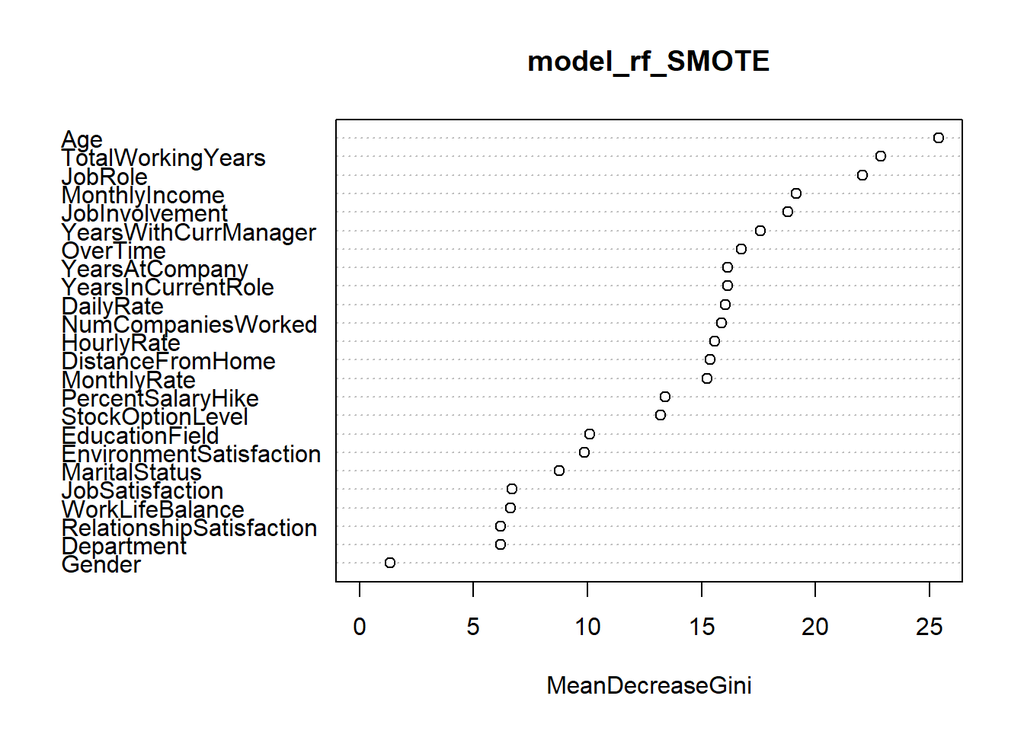

```r
## But random forest can provide with feature importance
varImpPlot(model_rf_SMOTE)
```

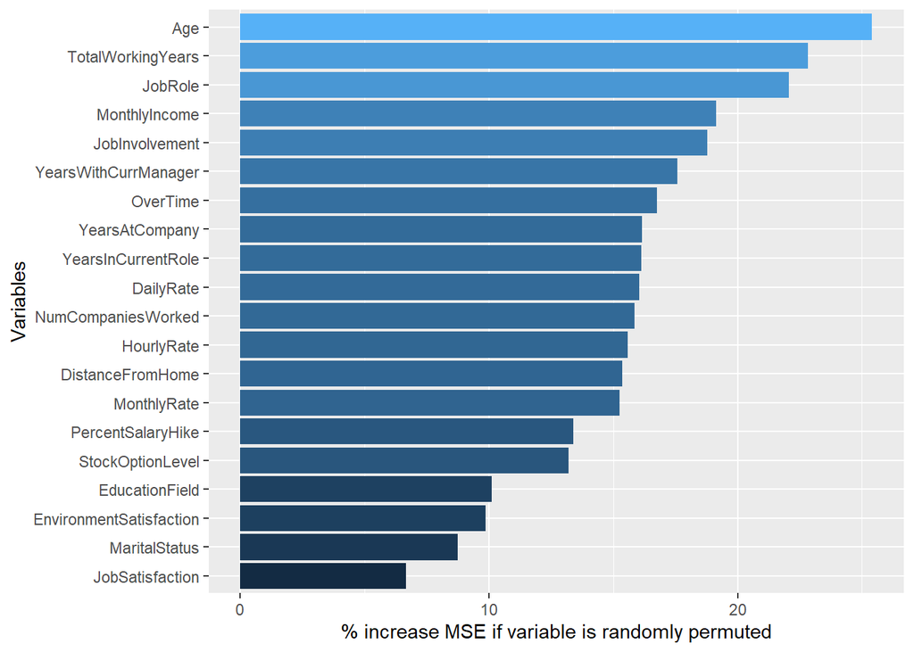

```r
imp_RF <- importance(model_rf_SMOTE)
imp_DF <- data.frame(Variables = row.names(imp_RF), MSE = imp_RF[,1])
imp_DF <- imp_DF[order(imp_DF$MSE, decreasing = TRUE),]

ggplot(imp_DF[1:20,], aes(x=reorder(Variables, MSE), y=MSE, fill=MSE)) + geom_bar(stat = 'identity') + labs(x = 'Variables', y= '% increase MSE if variable is randomly permuted') + coord_flip() + theme(legend.position="none")
```

```r
#cols <- c("Gender","Department","PerformanceRating","BusinessTravel")
cols <- c("RelationshipSatisfaction","EnvironmentSatisfaction")
smote_train[cols] <- NULL
valid_case2[cols] <- NULL

model_rf_SMOTE = randomForest(smote_train[,-c(2)],as.factor(smote_train$Attrition),ntree=500)
CM_rf_SMOTE = confusionMatrix(table(predict(model_rf_SMOTE,valid_case2[,-c(2)]),valid_case2$Attrition))
CM_rf_SMOTE
```

```
## Confusion Matrix and Statistics
##
##
##       0   1
##   0 183  16
##   1  36  26
##
##                Accuracy : 0.8008
##                  95% CI : (0.7471, 0.8475)
##     No Information Rate : 0.8391
##     P-Value [Acc > NIR] : 0.958464
##
##                   Kappa : 0.3813
##
##  Mcnemar's Test P-Value : 0.008418
##
##             Sensitivity : 0.8356
##             Specificity : 0.6190
##          Pos Pred Value : 0.9196
##          Neg Pred Value : 0.4194
##              Prevalence : 0.8391
##          Detection Rate : 0.7011
##    Detection Prevalence : 0.7625
##       Balanced Accuracy : 0.7273
##
##        'Positive' Class : 0
##
```

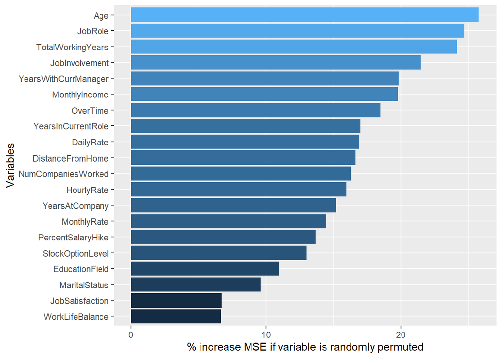

```r
imp_RF <- importance(model_rf_SMOTE)
imp_DF <- data.frame(Variables = row.names(imp_RF), MSE = imp_RF[,1])
imp_DF <- imp_DF[order(imp_DF$MSE, decreasing = TRUE),]

ggplot(imp_DF[1:20,], aes(x=reorder(Variables, MSE), y=MSE, fill=MSE)) + geom_bar(stat = 'identity') + labs(x = 'Variables', y= '% increase MSE if variable is randomly permuted') + coord_flip() + theme(legend.position="none")
```

## Fit MonthlyIncome

```r
set.seed(1000)
TrainObs = sample(seq(1,dim(case2_use_num)[1]),round(.7*dim(case2_use_num)[1]),replace = FALSE)
regresTrain = case2_use_num[TrainObs,]
#regresTrain
regresTest = case2_use_num[-TrainObs,]
#regresTest
Model1_fit = lm(MonthlyIncome~., data = regresTrain)

summary(Model1_fit)
```

```
##
## Call:
## lm(formula = MonthlyIncome ~ ., data = regresTrain)
##
## Residuals:
##      Min       1Q   Median       3Q      Max
## -10304.2  -1712.2    -38.8   1417.7  10781.1
##
## Coefficients:
##                           Estimate Std. Error t value Pr(>|t|)
## (Intercept)             2393.46457  929.91430   2.574   0.0103 *
## Age                      -22.17409   17.77695  -1.247   0.2128
## DailyRate                 -0.06159    0.29393  -0.210   0.8341
## DistanceFromHome          -7.36184   14.54067  -0.506   0.6128
## HourlyRate                -1.28693    5.91185  -0.218   0.8277
## MonthlyRate                0.01759    0.01675   1.050   0.2940
## NumCompaniesWorked      -135.32958   52.93035  -2.557   0.0108 *
## PercentSalaryHike        -15.18353   31.52598  -0.482   0.6303
## TotalWorkingYears        506.38638   27.73277  18.259   <2e-16 ***
## TrainingTimesLastYear      8.90219   91.74551   0.097   0.9227
## YearsAtCompany            43.14715   44.25905   0.975   0.3300
## YearsInCurrentRole       -41.06831   54.05196  -0.760   0.4477
## YearsSinceLastPromotion  -89.50923   49.98033  -1.791   0.0738 .
## YearsWithCurrManager     -31.65802   53.88787  -0.587   0.5571
## ---
## Signif. codes:  0 '***' 0.001 '**' 0.01 '*' 0.05 '.' 0.1 ' ' 1
##
## Residual standard error: 2872 on 595 degrees of freedom
## Multiple R-squared:  0.6135, Adjusted R-squared:  0.605
## F-statistic: 72.64 on 13 and 595 DF,  p-value: < 2.2e-16
```

```r
confint(Model1_fit)
```

```
##                                 2.5 %        97.5 %
## (Intercept)              567.15103222 4219.77810647
## Age                      -57.08729831   12.73911641
## DailyRate                 -0.63885934    0.51568163
## DistanceFromHome         -35.91912727   21.19544365
## HourlyRate               -12.89755877   10.32369670
## MonthlyRate               -0.01530255    0.05048753
## NumCompaniesWorked      -239.28262333  -31.37653770
## PercentSalaryHike        -77.09926096   46.73219616
## TotalWorkingYears        451.92036471  560.85239199
## TrainingTimesLastYear   -171.28221996  189.08659743
## YearsAtCompany           -43.77580340  130.07010355
## YearsInCurrentRole      -147.22413533   65.08752315
## YearsSinceLastPromotion -187.66855237    8.65008293
## YearsWithCurrManager    -137.49158861   74.17555757
```

```r
Model1_Preds = predict(Model1_fit, newdata = regresTest)

#MSPE Calculation
MSPE = mean((regresTest$MonthlyIncome - Model1_Preds)^2)
MSPE
```

```
## [1] 8522686
```

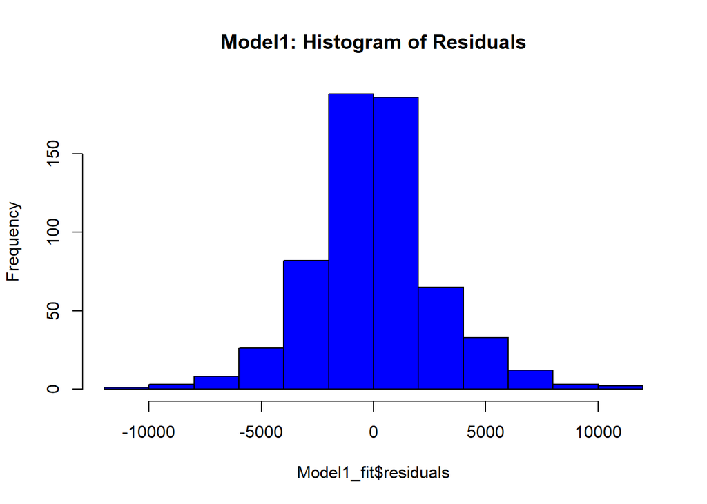

```r
hist(Model1_fit$residuals, col = "blue", main = "Model1: Histogram of Residuals")
```

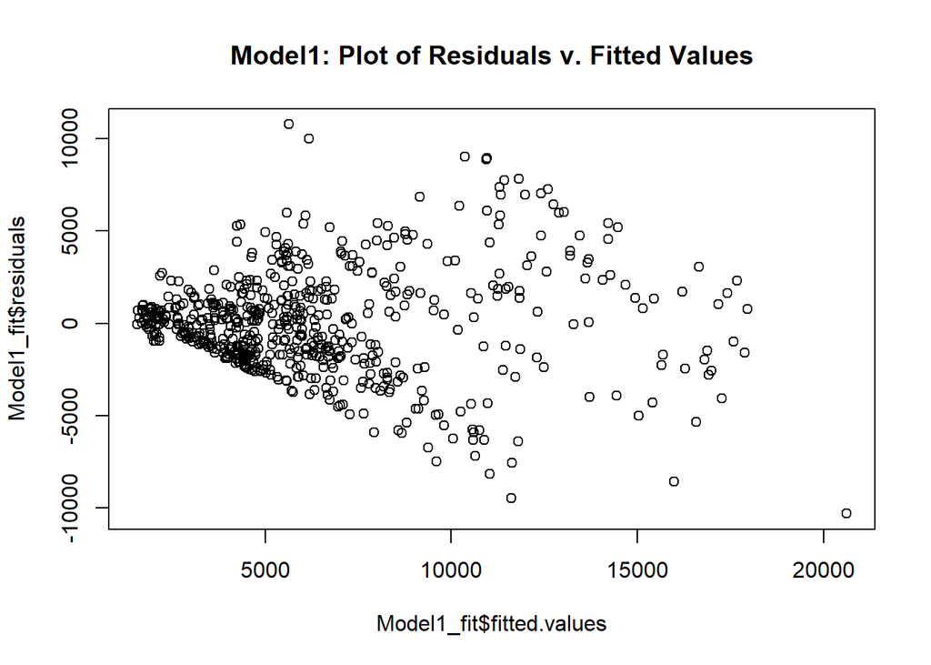

```r
plot(Model1_fit$fitted.values,Model1_fit$residuals, main = "Model1: Plot of Residuals v. Fitted Values")
```

```r
RSS_m1 <- c(crossprod(Model1_fit$residuals))
MSE_m1 <- RSS_m1 / length(Model1_fit$residuals)
RMSE_m1 <- sqrt(MSE_m1)
RMSE_m1
```

```
## [1] 2838.815
```

The variances from the model seems unequal, check histogram of MonthlyIncome

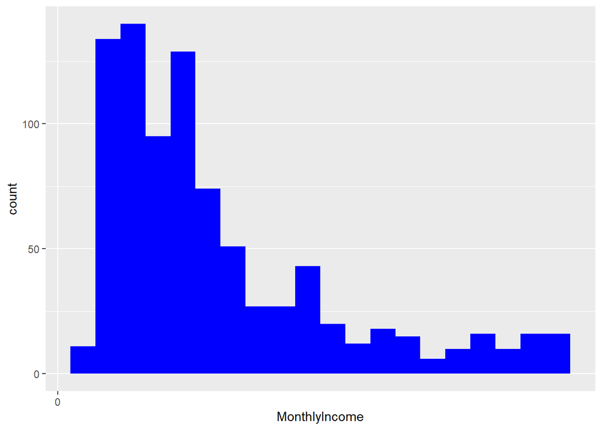

```r
ggplot(data=case2[!is.na(case2$MonthlyIncome),], aes(x=MonthlyIncome)) +
        geom_histogram(fill="blue", binwidth = 1000) +
        scale_x_continuous(breaks= seq(0, 800000, by=100000))
```